```python
import pandas as pd
import numpy as np
import matplotlib.pyplot as plt
import seaborn as sns

%matplotlib inline
```

# Leitura e entendimento dos dados

```python
df = pd.read_csv('Pokemon.csv')

df.info()

df.isna().sum()
```

```
<class 'pandas.core.frame.DataFrame'>
RangeIndex: 800 entries, 0 to 799
Data columns (total 13 columns):
#             800 non-null int64
Name          800 non-null object
Type 1        800 non-null object
Type 2        414 non-null object
Total         800 non-null int64
HP            800 non-null int64
Attack        800 non-null int64
Defense       800 non-null int64
Sp. Atk       800 non-null int64
Sp. Def       800 non-null int64
Speed         800 non-null int64
Generation    800 non-null int64
Legendary     800 non-null bool
dtypes: bool(1), int64(9), object(3)
memory usage: 75.9+ KB
```

```
#               0
Name            0
Type 1          0
Type 2        386
Total           0
HP              0
Attack          0
Defense         0
Sp. Atk         0
Sp. Def         0
Speed           0
Generation      0
Legendary       0
dtype: int64
```

```python
df.describe()
```

|  | # | Total | HP | Attack | Defense | Sp. Atk | Sp. Def | Speed | Generation |
| --- | --- | --- | --- | --- | --- | --- | --- | --- | --- |
| count | 800.000000 | 800.00000 | 800.000000 | 800.000000 | 800.000000 | 800.000000 | 800.000000 | 800.000000 | 800.00000 |
| mean | 362.813750 | 435.10250 | 69.258750 | 79.001250 | 73.842500 | 72.820000 | 71.902500 | 68.277500 | 3.32375 |
| std | 208.343798 | 119.96304 | 25.534669 | 32.457366 | 31.183501 | 32.722294 | 27.828916 | 29.060474 | 1.66129 |
| min | 1.000000 | 180.00000 | 1.000000 | 5.000000 | 5.000000 | 10.000000 | 20.000000 | 5.000000 | 1.00000 |
| 25% | 184.750000 | 330.00000 | 50.000000 | 55.000000 | 50.000000 | 49.750000 | 50.000000 | 45.000000 | 2.00000 |
| 50% | 364.500000 | 450.00000 | 65.000000 | 75.000000 | 70.000000 | 65.000000 | 70.000000 | 65.000000 | 3.00000 |
| 75% | 539.250000 | 515.00000 | 80.000000 | 100.000000 | 90.000000 | 95.000000 | 90.000000 | 90.000000 | 5.00000 |
| max | 721.000000 | 780.00000 | 255.000000 | 190.000000 | 230.000000 | 194.000000 | 230.000000 | 180.000000 | 6.00000 |

```python
df.head()
```

|  | # | Name | Type 1 | Type 2 | Total | HP | Attack | Defense | Sp. Atk | Sp. Def | Speed | Generation | Legendary |
| --- | --- | --- | --- | --- | --- | --- | --- | --- | --- | --- | --- | --- | --- |
| 0 | 1 | Bulbasaur | Grass | Poison | 318 | 45 | 49 | 49 | 65 | 65 | 45 | 1 | False |
| 1 | 2 | Ivysaur | Grass | Poison | 405 | 60 | 62 | 63 | 80 | 80 | 60 | 1 | False |
| 2 | 3 | Venusaur | Grass | Poison | 525 | 80 | 82 | 83 | 100 | 100 | 80 | 1 | False |
| 3 | 3 | VenusaurMega Venusaur | Grass | Poison | 625 | 80 | 100 | 123 | 122 | 120 | 80 | 1 | False |
| 4 | 4 | Charmander | Fire | NaN | 309 | 39 | 52 | 43 | 60 | 50 | 65 | 1 | False |

```python
df['Type 1'].unique()
```

```
array(['Grass', 'Fire', 'Water', 'Bug', 'Normal', 'Poison', 'Electric',
       'Ground', 'Fairy', 'Fighting', 'Psychic', 'Rock', 'Ghost', 'Ice',
       'Dragon', 'Dark', 'Steel', 'Flying'], dtype=object)
```

```python
len(df['Type 1'].unique())
```

```
18
```

```python
df['Type 2'].unique()
```

```
array(['Poison', nan, 'Flying', 'Dragon', 'Ground', 'Fairy', 'Grass',
       'Fighting', 'Psychic', 'Steel', 'Ice', 'Rock', 'Dark', 'Water',
       'Electric', 'Fire', 'Ghost', 'Bug', 'Normal'], dtype=object)
```

```python
len(df['Type 2'].unique())
```

```
19
```

```python
## Não há uma chave única

len(df['#'].unique())
```

```
721
```

```python
## Há oitocentos nomes! são únicos

len(df['Name'].unique())
```

```
800
```

Realizando uma análise exploratório inicial da nossa base de dados, podemos observar quais características temos para trabalhar, sendo elas: o tipo do pokemón (tipo 1 e tipo 2), o total de pontos, a quantidade de vida, os poderes de ataque e defesa, bem como a velocidade de cada um destes e a velocidade geral. Além disso, temos a informação de qual geração o pokemón é e se este é lendário ou não.

Como podemos observar todas as colunas possuem as 800 linhas (estamos trabalhando com 800 pokemóns diferentes), exceto a coluna "Type 2" visto que nem todos os pokemóns possuem dois tipos.

Por fim, afim de realizar as nossas contagens corretamente, identificamos como a chave principal do nosso banco de dados a coluna "Name", que possui 800 registros diferentes.

Concluimos, após este primeiro bloco que a base não precisa de nenhum tratamento ou preparação para a realização do EDA.

# Pokemóns lendários: qual o seu poder?

Vamos testar algumas hipóteses no que tange aos pokemóns lendários, quando comparados ao restante. Nossas perguntas são: os pokemóns lendários são mais poderosos? Eles possuem um poder de ataque maior?

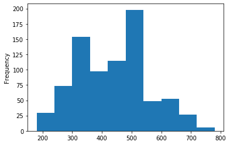

```python
df['Total'].plot.hist()
```

```python
df[['Name','HP', 'Legendary','Total']][df['Total']>=700]
```

|  | Name | HP | Legendary | Total |
| --- | --- | --- | --- | --- |
| 163 | MewtwoMega Mewtwo X | 106 | True | 780 |
| 164 | MewtwoMega Mewtwo Y | 106 | True | 780 |
| 268 | TyranitarMega Tyranitar | 100 | False | 700 |
| 409 | SalamenceMega Salamence | 95 | False | 700 |
| 413 | MetagrossMega Metagross | 80 | False | 700 |
| 418 | LatiasMega Latias | 80 | True | 700 |
| 420 | LatiosMega Latios | 80 | True | 700 |
| 422 | KyogrePrimal Kyogre | 100 | True | 770 |
| 424 | GroudonPrimal Groudon | 100 | True | 770 |
| 426 | RayquazaMega Rayquaza | 105 | True | 780 |
| 494 | GarchompMega Garchomp | 108 | False | 700 |
| 552 | Arceus | 120 | True | 720 |
| 711 | KyuremBlack Kyurem | 125 | True | 700 |
| 712 | KyuremWhite Kyurem | 125 | True | 700 |
| 796 | DiancieMega Diancie | 50 | True | 700 |

Inicialmente, plotamos o histograma da variável "Total" para entender como é a sua distribuição. Vimos que a partir de 700 pontos, há poucos pokemóns. Nossa ideia inicialmente é que este grupo seria apenas de pokemóns lendários, ou seja, eles estariam concentrados na cauda direira. No entanto, vimos que dos 15 pokemóns que possuem 700 ou mais pontos, 11 são lendários. Sendo que, a maior pontuação é sim dos pokemóns lendários. Aqueles 4 pokemóns não lendários que possuem 700 pontos são evoluções muito grandes, podemos identificar isso pelos nomes, nos quais todos possuem "Mega".

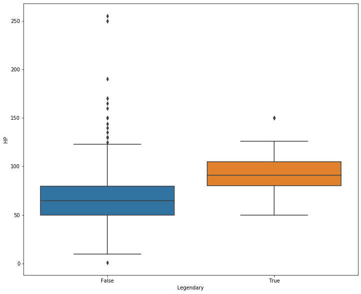

```python
plt.figure(figsize=(12,10))
sns.boxplot(data=df, x='Legendary', y='HP')
plt.show()
```

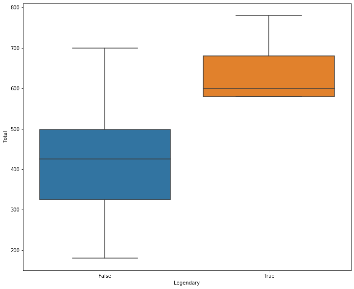

```python
plt.figure(figsize=(12,10))
sns.boxplot(data=df, x='Legendary', y='Total')
plt.show()
```

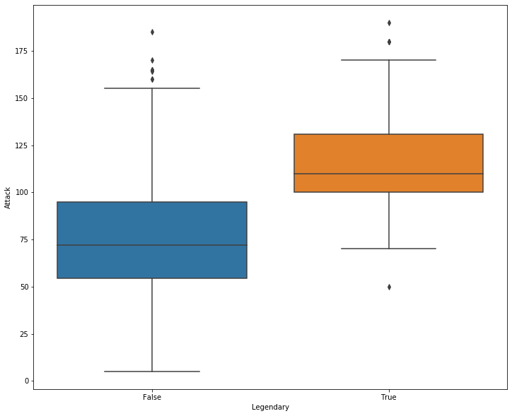

```python
plt.figure(figsize=(12,10))
sns.boxplot(data=df, x='Legendary', y='Attack')
plt.show()
```

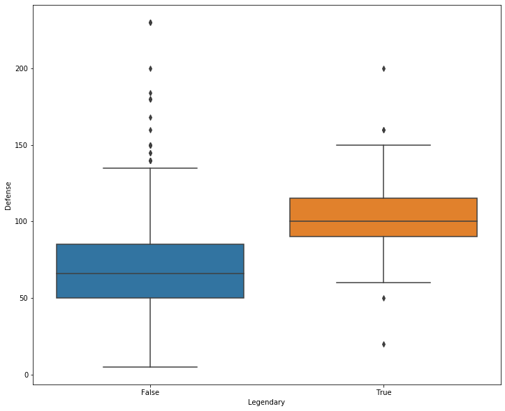

```python
plt.figure(figsize=(12,10))
sns.boxplot(data=df, x='Legendary', y='Defense')
plt.show()
```

```python
df[['Name','Legendary','Defense']][df['Defense']>=125].sort_values(['Defense'])
```

|  | Name | Legendary | Defense |
| --- | --- | --- | --- |
| 516 | Tangrowth | False | 125 |
| 523 | Gliscor | False | 125 |
| 150 | Omastar | False | 125 |
| 619 | Crustle | False | 125 |
| 327 | SableyeMega Sableye | False | 125 |
| 329 | MawileMega Mawile | False | 125 |
| 591 | AudinoMega Audino | False | 126 |
| 699 | Cobalion | True | 129 |
| 521 | Leafeon | False | 130 |
| 537 | Uxie | True | 130 |
| 585 | Gigalith | False | 130 |
| 412 | Metagross | False | 130 |
| 409 | SalamenceMega Salamence | False | 130 |
| 404 | Relicanth | False | 130 |
| 389 | Dusclops | False | 130 |
| 515 | Rhyperior | False | 130 |
| 82 | Golem | False | 130 |
| 269 | Lugia | True | 130 |
| 659 | Ferrothorn | False | 131 |
| 626 | Carracosta | False | 133 |
| 529 | Dusknoir | False | 135 |
| 323 | Nosepass | False | 135 |
| 355 | Torkoal | False | 140 |
| 245 | Skarmory | False | 140 |
| 229 | ScizorMega Scizor | False | 140 |
| 220 | Forretress | False | 140 |
| 423 | Groudon | True | 140 |
| 331 | Lairon | False | 140 |
| 624 | Cofagrigus | False | 145 |
| 528 | Probopass | False | 145 |
| 749 | Doublade | False | 150 |
| 751 | AegislashShield Forme | False | 150 |
| 773 | Carbink | False | 150 |
| 413 | MetagrossMega Metagross | False | 150 |
| 416 | Registeel | True | 150 |
| 268 | TyranitarMega Tyranitar | False | 150 |
| 795 | Diancie | True | 150 |
| 430 | DeoxysDefense Forme | True | 160 |
| 424 | GroudonPrimal Groudon | True | 160 |
| 103 | Onix | False | 160 |
| 456 | Bastiodon | False | 168 |
| 332 | Aggron | False | 180 |
| 98 | Cloyster | False | 180 |
| 87 | SlowbroMega Slowbro | False | 180 |
| 789 | Avalugg | False | 184 |
| 414 | Regirock | True | 200 |
| 223 | Steelix | False | 200 |
| 333 | AggronMega Aggron | False | 230 |
| 230 | Shuckle | False | 230 |
| 224 | SteelixMega Steelix | False | 230 |

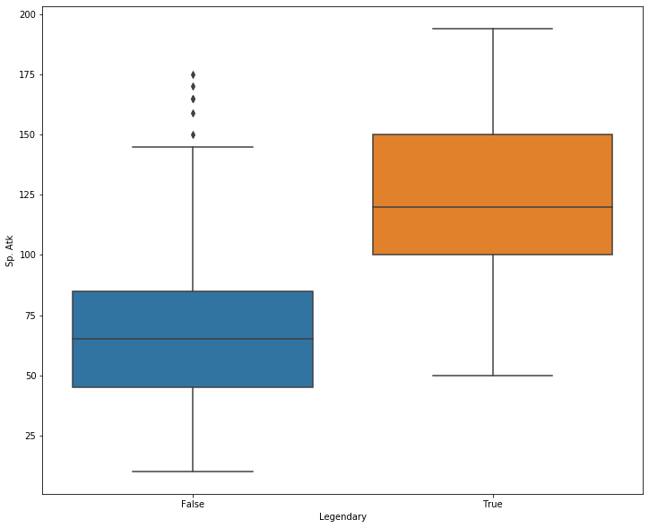

```python
plt.figure(figsize=(12,10))
sns.boxplot(data=df, x='Legendary', y='Sp. Atk')
plt.show()
```

```python
df[['Name','Legendary','Sp. Atk']][df['Sp. Atk']>=140].sort_values(['Sp. Atk'])
```

|  | Name | Legendary | Sp. Atk |
| --- | --- | --- | --- |
| 616 | DarmanitanZen Mode | False | 140 |
| 248 | HoundoomMega Houndoom | False | 140 |
| 498 | LucarioMega Lucario | False | 140 |
| 418 | LatiasMega Latias | True | 140 |
| 705 | ThundurusTherian Forme | True | 145 |
| 670 | Chandelure | False | 145 |
| 275 | SceptileMega Sceptile | False | 145 |
| 354 | CameruptMega Camerupt | False | 145 |
| 425 | Rayquaza | True | 150 |
| 797 | HoopaHoopa Confined | True | 150 |
| 540 | Dialga | True | 150 |
| 421 | Kyogre | True | 150 |
| 424 | GroudonPrimal Groudon | True | 150 |
| 706 | Reshiram | True | 150 |
| 750 | AegislashBlade Forme | False | 150 |
| 541 | Palkia | True | 150 |
| 428 | DeoxysNormal Forme | True | 150 |
| 163 | MewtwoMega Mewtwo X | True | 154 |
| 162 | Mewtwo | True | 154 |
| 8 | CharizardMega Charizard Y | False | 159 |
| 420 | LatiosMega Latios | True | 160 |
| 796 | DiancieMega Diancie | True | 160 |
| 306 | GardevoirMega Gardevoir | False | 165 |
| 196 | AmpharosMega Ampharos | False | 165 |
| 102 | GengarMega Gengar | False | 170 |
| 712 | KyuremWhite Kyurem | True | 170 |
| 798 | HoopaHoopa Unbound | True | 170 |
| 71 | AlakazamMega Alakazam | False | 175 |
| 426 | RayquazaMega Rayquaza | True | 180 |
| 422 | KyogrePrimal Kyogre | True | 180 |
| 429 | DeoxysAttack Forme | True | 180 |
| 164 | MewtwoMega Mewtwo Y | True | 194 |

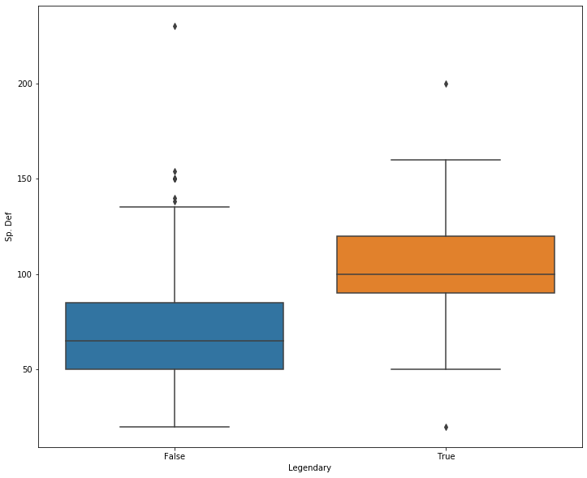

```python
plt.figure(figsize=(12,10))
sns.boxplot(data=df, x='Legendary', y='Sp. Def')
plt.show()
```

```python
df[['Name','Legendary','Sp. Def']][df['Sp. Def']>=125].sort_values(['Sp. Def'])
```

|  | Name | Legendary | Sp. Def |
| --- | --- | --- | --- |
| 156 | Articuno | True | 125 |
| 382 | Milotic | False | 125 |
| 591 | AudinoMega Audino | False | 126 |
| 715 | MeloettaAria Forme | False | 128 |
| 701 | Virizion | True | 129 |
| 141 | GyaradosMega Gyarados | False | 130 |
| 770 | Sylveon | False | 130 |
| 546 | Cresselia | False | 130 |
| 537 | Uxie | True | 130 |
| 797 | HoopaHoopa Confined | True | 130 |
| 417 | Latias | True | 130 |
| 798 | HoopaHoopa Unbound | True | 130 |
| 389 | Dusclops | False | 130 |
| 212 | Umbreon | False | 130 |
| 261 | Blissey | False | 135 |
| 306 | GardevoirMega Gardevoir | False | 135 |
| 529 | Dusknoir | False | 135 |
| 676 | Cryogonal | False | 135 |
| 456 | Bastiodon | False | 138 |
| 421 | Kyogre | True | 140 |
| 244 | Mantine | False | 140 |
| 795 | Diancie | True | 150 |
| 776 | Goodra | False | 150 |
| 773 | Carbink | False | 150 |
| 751 | AegislashShield Forme | False | 150 |
| 416 | Registeel | True | 150 |
| 528 | Probopass | False | 150 |
| 418 | LatiasMega Latias | True | 150 |
| 739 | Florges | False | 154 |
| 269 | Lugia | True | 154 |
| 270 | Ho-oh | True | 154 |
| 422 | KyogrePrimal Kyogre | True | 160 |
| 430 | DeoxysDefense Forme | True | 160 |
| 415 | Regice | True | 200 |
| 230 | Shuckle | False | 230 |

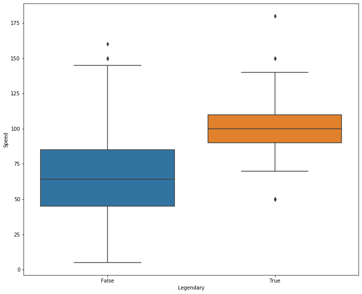

```python
plt.figure(figsize=(12,10))
sns.boxplot(data=df, x='Legendary', y='Speed')
plt.show()
```

```python
df[['Name','Legendary','Speed']][df['Speed']>=125].sort_values(['Speed'])
```

|  | Name | Legendary | Speed |
| --- | --- | --- | --- |
| 300 | Swellow | False | 125 |
| 549 | Darkrai | True | 125 |
| 512 | Weavile | False | 125 |
| 731 | Talonflame | False | 126 |
| 551 | ShayminSky Forme | True | 127 |
| 716 | MeloettaPirouette Forme | False | 128 |
| 146 | Jolteon | False | 130 |
| 153 | Aerodactyl | False | 130 |
| 162 | Mewtwo | True | 130 |
| 163 | MewtwoMega Mewtwo X | True | 130 |
| 102 | GengarMega Gengar | False | 130 |
| 183 | Crobat | False | 130 |
| 476 | LopunnyMega Lopunny | False | 135 |
| 339 | ManectricMega Manectric | False | 135 |
| 109 | Electrode | False | 140 |
| 164 | MewtwoMega Mewtwo Y | True | 140 |
| 275 | SceptileMega Sceptile | False | 145 |
| 678 | Accelgor | False | 145 |
| 19 | BeedrillMega Beedrill | False | 145 |
| 428 | DeoxysNormal Forme | True | 150 |
| 429 | DeoxysAttack Forme | True | 150 |
| 71 | AlakazamMega Alakazam | False | 150 |
| 154 | AerodactylMega Aerodactyl | False | 150 |
| 315 | Ninjask | False | 160 |
| 431 | DeoxysSpeed Forme | True | 180 |

Plotando, para cada característica do pokemón, podemos observar e responder a nossa pergunta inicial de o quão poderosos são os pokemóns lendários quando comparados ao pokemóns normais. Quando observamos a mediana do boxplot, para todas as características, os lendários apresentam melhores desempenhos. No entanto, podemos perceber a presença de outliers. Para as variáveis "Hp", "Defense" e "Sp. def", os pokemóns com melhores desempenhos não são lendários. No que tange a característica "Defense", os 4 primeiros com melhor desempenho não são lendários. Vemos outliers também para outras características, como por exemplo, "Sp. Def." no qual o pokemón que possui a maior velocidade de defesa é o Shuckle, não lendário. Para "Speed" temos alguns outliers não lendários que são bem rápidos. O segundo pokemón (Ninjask) mais rápido não é lendário!

```python
labels=np.array(['HP', 'Attack', 'Defense', 'Sp. Atk', 'Sp. Def', 'Speed'])
stats = np.array(df[df["Legendary"] == True][labels].mean())
stats2 = np.array(df[df["Legendary"] == False][labels].mean())
```

```python
angles = np.linspace(0, 2*np.pi, len(labels), endpoint=False)
stats = np.concatenate((stats, [stats[0]]))
stats2 = np.concatenate((stats2, [stats2[0]]))
angles = np.concatenate((angles, [angles[0]]))
```

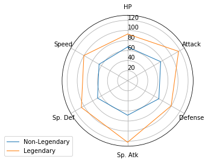

```python
ax = plt.subplot(111, polar=True)
ax.set_theta_offset(np.pi / 2)
ax.set_theta_direction(-1)

plt.xticks(angles[:-1], labels)

ax.set_rlabel_position(0)
plt.ylim(0,130)

values=stats2
ax.plot(angles, values, linewidth=1, linestyle="solid", label="Non-Legendary")
#ax.fill(angles, values, 'r', alpha=0.5)

values=stats
ax.plot(angles, values, linewidth=1, linestyle="solid", label="Legendary")
#ax.fill(angles, values, 'b', alpha=0.1)

plt.legend(loc='upper right', bbox_to_anchor=(0.1, 0.1))
```

## A correlação entre os principais atributos

Agora, iremos identificar a correlação entre os principais atributos: HP; Attack; Defense; Sp. Atk; Sp. Def; e Speed. A correlação é importante para identificarmos a interdependência entre as variáveis e, com isso, confirmar ou refutar algumas hipóteses.

```python
labels=np.array(['HP','Attack','Defense','Sp. Atk','Sp. Def','Speed'])

df[labels].corr().style.format("{:.2}").background_gradient(cmap=plt.get_cmap('coolwarm'), axis=1)
```

|  | HP | Attack | Defense | Sp. Atk | Sp. Def | Speed |
| --- | --- | --- | --- | --- | --- | --- |
| HP | 1.0 | 0.42 | 0.24 | 0.36 | 0.38 | 0.18 |
| Attack | 0.42 | 1.0 | 0.44 | 0.4 | 0.26 | 0.38 |
| Defense | 0.24 | 0.44 | 1.0 | 0.22 | 0.51 | 0.015 |
| Sp. Atk | 0.36 | 0.4 | 0.22 | 1.0 | 0.51 | 0.47 |
| Sp. Def | 0.38 | 0.26 | 0.51 | 0.51 | 1.0 | 0.26 |
| Speed | 0.18 | 0.38 | 0.015 | 0.47 | 0.26 | 1.0 |

Como podemos visualizar na matriz de correlação acima, não há nenhum par de variáveis com uma forte correlação (seja positiva ou negativa). A princípio, esperávamos que Pokemons com valores altos em 'Attack' possuissem também valores altos em 'Sp. Atk' e a mesma ideia para o caso dos atributos 'Defense' e 'Sp. Def'. Mas o que podemos observar são correlações entre 40% e 50% entre esses pares.

Também podemos notar que a correlação da velocidade (Speed) com velocidade de defesa é 20% menor se comparado com a velocidade de ataque. Além disso, Pokemons com valores mais altos de ataque tendem a ter valores mais altos de HP - existe uma correlação maior entre ataque e HP do que entre defesa e HP.

```python
### Analisando Correlacao entre os Pokemons Lendarios
labels=np.array(['HP','Attack','Defense','Sp. Atk','Sp. Def','Speed'])
df1 = df[labels][df["Legendary"] == True]

df1[labels].corr().style.format("{:.2}").background_gradient(cmap=plt.get_cmap('coolwarm'), axis=1)
```

|  | HP | Attack | Defense | Sp. Atk | Sp. Def | Speed |
| --- | --- | --- | --- | --- | --- | --- |
| HP | 1.0 | 0.18 | 0.077 | 0.03 | 0.017 | -0.14 |
| Attack | 0.18 | 1.0 | -0.21 | 0.57 | -0.39 | 0.27 |
| Defense | 0.077 | -0.21 | 1.0 | -0.51 | 0.38 | -0.53 |
| Sp. Atk | 0.03 | 0.57 | -0.51 | 1.0 | -0.15 | 0.31 |
| Sp. Def | 0.017 | -0.39 | 0.38 | -0.15 | 1.0 | -0.49 |
| Speed | -0.14 | 0.27 | -0.53 | 0.31 | -0.49 | 1.0 |

Considerando agora apenas os Pokemons lendários, podemos observar algumas correlações mais fortes. Nessa categoria, existe uma correlação maior entre ataque e velocidade de ataque (57%) e, chama atenção, a presença de correlações negativas, especialmente entre defesa e os atributos 'velocidade' e 'velocidade de ataque'. Ou seja, Pokemons lendários quando possuem valores altos para 'defesa' tendem a possuir uma baixa mobilidade.

```python
### Analisando Correlacao entre os Pokemons Nao Lendarios
labels=np.array(['HP','Attack','Defense','Sp. Atk','Sp. Def','Speed'])
df2 = df[labels][df["Legendary"] == False]

df2[labels].corr().style.format("{:.2}").background_gradient(cmap=plt.get_cmap('coolwarm'), axis=1)
```

|  | HP | Attack | Defense | Sp. Atk | Sp. Def | Speed |
| --- | --- | --- | --- | --- | --- | --- |
| HP | 1.0 | 0.38 | 0.19 | 0.3 | 0.34 | 0.11 |
| Attack | 0.38 | 1.0 | 0.44 | 0.26 | 0.21 | 0.31 |
| Defense | 0.19 | 0.44 | 1.0 | 0.19 | 0.48 | -0.041 |
| Sp. Atk | 0.3 | 0.26 | 0.19 | 1.0 | 0.47 | 0.39 |
| Sp. Def | 0.34 | 0.21 | 0.48 | 0.47 | 1.0 | 0.21 |
| Speed | 0.11 | 0.31 | -0.041 | 0.39 | 0.21 | 1.0 |

Por fim, olhando apenas para os Pokemons não lendários, maioria, não observa-se muitas correlações negativas a exemplo do que foi visto para os lendários. Apenas entre defesa e velocidade é que podemos visualizar uma negativa, mesmo assim é praticamente uma correlação nula. No demais, nenhuma forte correlação é indicada.

## O poder de cada tipo.

Neste segundo momento, queremos entender como os poderes dos pokemóns variam de acordo com os seus tipos.

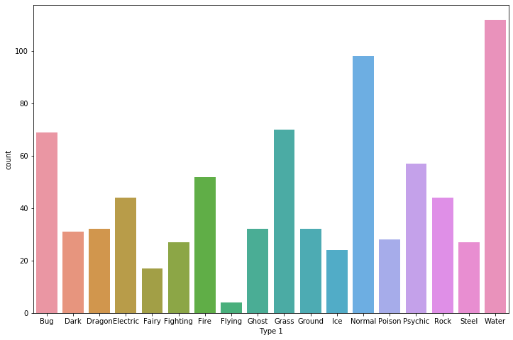

```python
plt.figure(figsize=(12,8))
sns.countplot(df['Type 1'].sort_values())
plt.show()
```

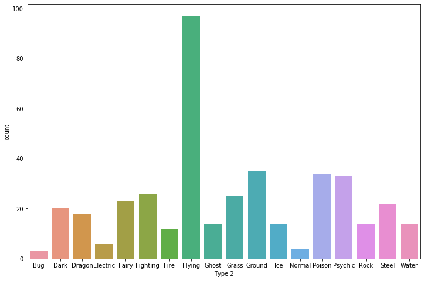

```python
plt.figure(figsize=(12,8))
sns.countplot(df['Type 2'].sort_values())
plt.show()
```

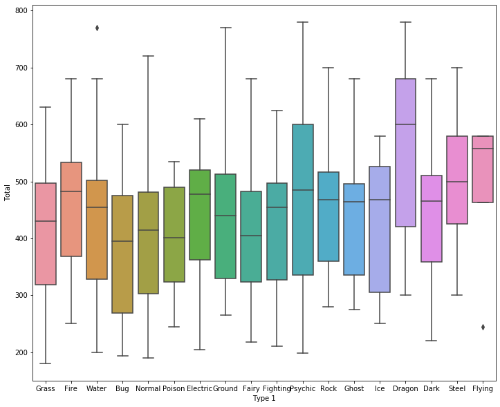

```python
plt.figure(figsize=(12,10))
sns.boxplot(data=df, x='Type 1', y='Total')
plt.show()
```

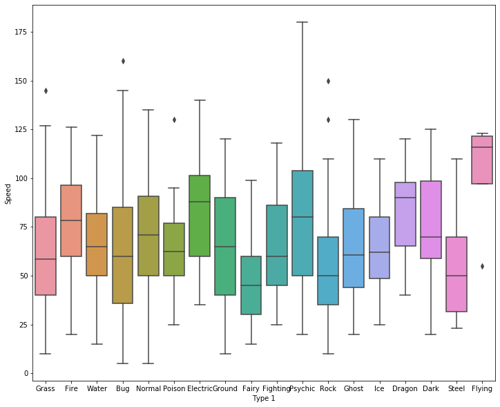

```python
plt.figure(figsize=(12,10))
sns.boxplot(data=df, x='Type 1', y='Speed')
plt.show()
```

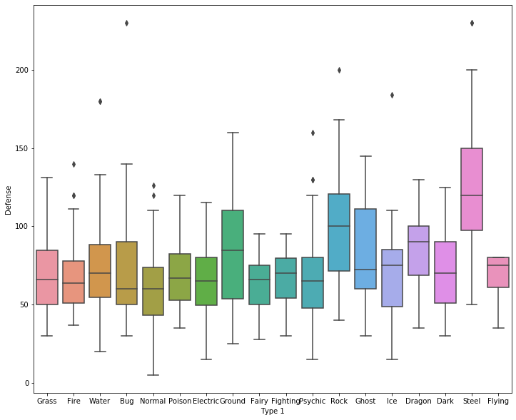

```python
plt.figure(figsize=(12,10))
sns.boxplot(data=df, x='Type 1', y='Defense')
plt.show()
```

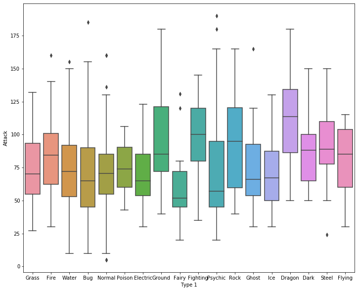

```python
plt.figure(figsize=(12,10))
sns.boxplot(data=df, x='Type 1', y='Attack')
plt.show()
```

```python
from collections import Counter

labels=np.array(['HP', 'Attack', 'Defense', 'Sp. Atk', 'Sp. Def', 'Speed'])
tipos = df["Type 1"].unique()
tipos = sorted(tipos, key=Counter(df["Type 1"]).get, reverse=True)

stats = np.array(df[df["Type 1"] == tipos[0]][labels].mean())
stats2 = np.array(df[df["Type 1"] == tipos[1]][labels].mean())
stats3 = np.array(df[df["Type 1"] == tipos[2]][labels].mean())
stats4 = np.array(df[df["Type 1"] == tipos[3]][labels].mean())
stats5 = np.array(df[df["Type 1"] == tipos[4]][labels].mean())
```

```python
angles = np.linspace(0, 2*np.pi, len(labels), endpoint=False)
stats = np.concatenate((stats, [stats[0]]))
stats2 = np.concatenate((stats2, [stats2[0]]))
stats3 = np.concatenate((stats3, [stats2[0]]))
stats4 = np.concatenate((stats4, [stats2[0]]))
stats5 = np.concatenate((stats5, [stats2[0]]))
angles = np.concatenate((angles, [angles[0]]))
```

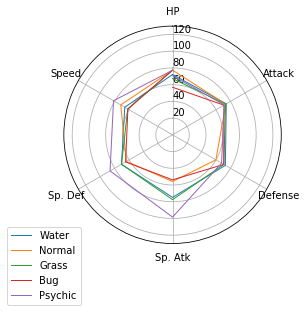

```python
ax = plt.subplot(111, polar=True)
ax.set_theta_offset(np.pi / 2)
ax.set_theta_direction(-1)

plt.xticks(angles[:-1], labels)

ax.set_rlabel_position(0)
plt.ylim(0,130)

values=stats
ax.plot(angles, values, linewidth=1, linestyle="solid", label=tipos[0])

values=stats2
ax.plot(angles, values, linewidth=1, linestyle="solid", label=tipos[1])

values=stats3
ax.plot(angles, values, linewidth=1, linestyle="solid", label=tipos[2])

values=stats4
ax.plot(angles, values, linewidth=1, linestyle="solid", label=tipos[3])

values=stats5
ax.plot(angles, values, linewidth=1, linestyle="solid", label=tipos[4])


plt.legend(loc='upper right', bbox_to_anchor=(0.1, 0.1))
```

Uma análise aplicada para verificar os diferentes valores de atributos entre os tipos 1 dos pokemons foi a criação de um gráfico radar. Dessa forma, foram selecionados os 5 tipos 1 mais frequentes e plotados seus valores médios. Verificando o gráfico acima vemos que existe um grande equilíbrio entre os valores, com algumas alterações dependendo do atributo. Entretanto, é possível notar que o tipo Psychic parece ser superior na média em 3 atributos, os que envolvem velocidade.

Apesar de ter sido aplicada para apenas os 5 tipos 1 mais frequentes essa análise pode ser generalizada para comparar os atributos entre diversos tipos, dependendo do interesse e hipótese que se deseja verificar.

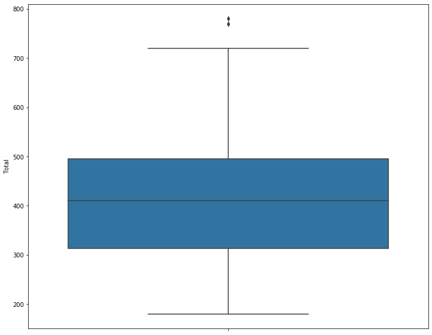

```python
plt.figure(figsize=(12,10))
sns.boxplot(data=df[df['Type 2'].isna()], y='Total')
plt.show()
```

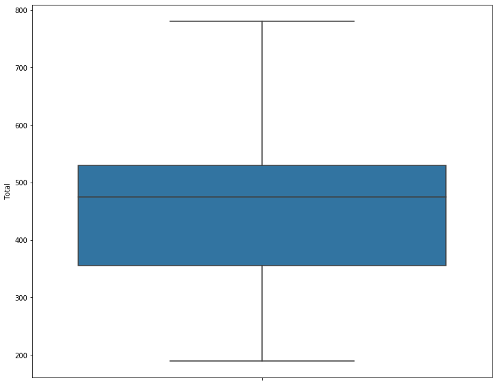

```python
plt.figure(figsize=(12,10))
sns.boxplot(data=df[df['Type 2'].notnull()], y='Total')
plt.show()
```

Por fim, gostariamos de entender se há uma diferença de poder quando comparamos aqueles pokemóns que possuem apenas um tipo com aqueles que possuem dois tipos. Lembrando que apenas 414 pokemóns dos 800, possuem dois tipos associados. O primeiro plot é para aqueles que possuem apenas um tipo associado e o segundo para aqueles que possuem 2. E como podemos constatar pela análise gráfica, sim, os pokemóns que são de 2 tipos tendem a ter um melhor desempenho no que tange ao "Total".